# Practical Machine Learning Course Project

Roberto Diaz Ortega

20/6/2017

## Background

Using devices such as Jawbone Up, Nike FuelBand, and Fitbit it is now possible to collect a large amount of data about personal activity relatively inexpensively. These type of devices are part of the quantified self movement - a group of enthusiasts who take measurements about themselves regularly to improve their health, to find patterns in their behavior, or because they are tech geeks. One thing that people regularly do is quantify how much of a particular activity they do, but they rarely quantify how well they do it. In this project, your goal will be to use data from accelerometers on the belt, forearm, arm, and dumbell of 6 participants. They were asked to perform barbell lifts correctly and incorrectly in 5 different ways. More information is available from the website here: http://groupware.les.inf.puc-rio.br/har (see the section on the Weight Lifting Exercise Dataset).

## Getting Data

The first step to perfom the study is get the data from the provided Urls:

```r
trainUrl <- "http://d396qusza40orc.cloudfront.net/predmachlearn/pml-training.csv"
testUrl <- "http://d396qusza40orc.cloudfront.net/predmachlearn/pml-testing.csv"

train_complete_dataset <- read.csv(url(trainUrl), na.strings=c("NA","#DIV/0!",""))
test_complete_dataset <- read.csv(url(testUrl), na.strings=c("NA","#DIV/0!",""))
```

## Data Cleaning

```r
dim(train_complete_dataset)
```

```
## [1] 19622   160
```

```r
dim(test_complete_dataset)
```

```
## [1]  20 160
```

```r
colSums(is.na(train_complete_dataset))
```

```
##                        X                user_name     raw_timestamp_part_1
##                        0                        0                        0
##     raw_timestamp_part_2           cvtd_timestamp               new_window
##                        0                        0                        0
##               num_window                roll_belt               pitch_belt
##                        0                        0                        0
##                 yaw_belt         total_accel_belt       kurtosis_roll_belt
##                        0                        0                    19226
##      kurtosis_picth_belt        kurtosis_yaw_belt       skewness_roll_belt
##                    19248                    19622                    19225
##     skewness_roll_belt.1        skewness_yaw_belt            max_roll_belt
##                    19248                    19622                    19216
##           max_picth_belt             max_yaw_belt            min_roll_belt
##                    19216                    19226                    19216
##           min_pitch_belt             min_yaw_belt      amplitude_roll_belt
##                    19216                    19226                    19216
##     amplitude_pitch_belt       amplitude_yaw_belt     var_total_accel_belt
##                    19216                    19226                    19216
##            avg_roll_belt         stddev_roll_belt            var_roll_belt
##                    19216                    19216                    19216
##           avg_pitch_belt        stddev_pitch_belt           var_pitch_belt
##                    19216                    19216                    19216
##             avg_yaw_belt          stddev_yaw_belt             var_yaw_belt
##                    19216                    19216                    19216
##             gyros_belt_x             gyros_belt_y             gyros_belt_z
##                        0                        0                        0
##             accel_belt_x             accel_belt_y             accel_belt_z
##                        0                        0                        0
##            magnet_belt_x            magnet_belt_y            magnet_belt_z
##                        0                        0                        0
##                 roll_arm                pitch_arm                  yaw_arm
##                        0                        0                        0
##          total_accel_arm            var_accel_arm             avg_roll_arm
##                        0                    19216                    19216
##          stddev_roll_arm             var_roll_arm            avg_pitch_arm
##                    19216                    19216                    19216
##         stddev_pitch_arm            var_pitch_arm              avg_yaw_arm
##                    19216                    19216                    19216
##           stddev_yaw_arm              var_yaw_arm              gyros_arm_x
##                    19216                    19216                        0
```

[output cut: 53 more lines]

```
##                    19300                        0                    19216
##         avg_roll_forearm      stddev_roll_forearm         var_roll_forearm
##                    19216                    19216                    19216
##        avg_pitch_forearm     stddev_pitch_forearm        var_pitch_forearm
##                    19216                    19216                    19216
##          avg_yaw_forearm       stddev_yaw_forearm          var_yaw_forearm
##                    19216                    19216                    19216
##          gyros_forearm_x          gyros_forearm_y          gyros_forearm_z
##                        0                        0                        0
##          accel_forearm_x          accel_forearm_y          accel_forearm_z
##                        0                        0                        0
##         magnet_forearm_x         magnet_forearm_y         magnet_forearm_z
##                        0                        0                        0
##                   classe
##                        0
```

As it can be observed there are a lot of columns that are NA, so the datasets will be cleaned in order to remove all empty columns and data. Additionally some columns not neccessary for the study are also removed:

```r
#Cleaning training dataset
empty_data <- is.na(train_complete_dataset)
columns_to_delete <- which(colSums(empty_data) > 1900) #remove columns with >=10%  of NA
train_complete_dataset <- train_complete_dataset[, -columns_to_delete]
train_complete_dataset <- train_complete_dataset[-c(1:7)]

#Cleaning testing dataset
empty_data <- is.na(test_complete_dataset)
columns_to_delete <- which(colSums(empty_data) > 2) #remove columns with >=10% of NA
test_complete_dataset <- test_complete_dataset[, -columns_to_delete]
test_complete_dataset <- test_complete_dataset[-c(1:7)]

dim(train_complete_dataset)
```

```
## [1] 19622    53
```

```r
dim(test_complete_dataset)
```

```
## [1] 20 53
```

```r
colSums(is.na(train_complete_dataset))
```

```
##            roll_belt           pitch_belt             yaw_belt
##                    0                    0                    0
##     total_accel_belt         gyros_belt_x         gyros_belt_y
##                    0                    0                    0
##         gyros_belt_z         accel_belt_x         accel_belt_y
##                    0                    0                    0
##         accel_belt_z        magnet_belt_x        magnet_belt_y
##                    0                    0                    0
##        magnet_belt_z             roll_arm            pitch_arm
##                    0                    0                    0
##              yaw_arm      total_accel_arm          gyros_arm_x
##                    0                    0                    0
##          gyros_arm_y          gyros_arm_z          accel_arm_x
##                    0                    0                    0
##          accel_arm_y          accel_arm_z         magnet_arm_x
##                    0                    0                    0
##         magnet_arm_y         magnet_arm_z        roll_dumbbell
##                    0                    0                    0
##       pitch_dumbbell         yaw_dumbbell total_accel_dumbbell
##                    0                    0                    0
##     gyros_dumbbell_x     gyros_dumbbell_y     gyros_dumbbell_z
##                    0                    0                    0
##     accel_dumbbell_x     accel_dumbbell_y     accel_dumbbell_z
##                    0                    0                    0
##    magnet_dumbbell_x    magnet_dumbbell_y    magnet_dumbbell_z
##                    0                    0                    0
##         roll_forearm        pitch_forearm          yaw_forearm
##                    0                    0                    0
##  total_accel_forearm      gyros_forearm_x      gyros_forearm_y
##                    0                    0                    0
##      gyros_forearm_z      accel_forearm_x      accel_forearm_y
##                    0                    0                    0
##      accel_forearm_z     magnet_forearm_x     magnet_forearm_y
##                    0                    0                    0
##     magnet_forearm_z               classe
##                    0                    0
```

## Preparing the prediction dataset

In order to perform a cross validation the 70% of the train dataset will be used to create the model and the rest 30% will be use to validate the model:

```r
library(caret)
set.seed(13579)
train_dataset_indexs <- createDataPartition(y=train_complete_dataset$classe,p=.70,list=F)

train_dataset <- train_complete_dataset[train_dataset_indexs,]
validate_dataset <- train_complete_dataset[-train_dataset_indexs,]
```

## Modeling

Due to in the guideline do not mention anything about the modeling method, in this case we are going to use the random forest model as following:

```r
library(randomForest)
model <- randomForest(classe~.,data=train_dataset)
model
```

```
##
## Call:
##  randomForest(formula = classe ~ ., data = train_dataset)
##                Type of random forest: classification
##                      Number of trees: 500
## No. of variables tried at each split: 7
##
##         OOB estimate of  error rate: 0.53%
## Confusion matrix:
##      A    B    C    D    E  class.error
## A 3904    2    0    0    0 0.0005120328
## B   14 2636    8    0    0 0.0082768999
## C    0   10 2385    1    0 0.0045909850
## D    0    0   28 2222    2 0.0133214920
## E    0    0    3    5 2517 0.0031683168
```

After running the Random Forest, the obtained model has an out of the bag error rate of 0.53% and taking a quick look to the confusion matrix it can be observed how the model has a quite good behaviour classifing the training input dataset. In the following plot is showed the most importance variables for the model:

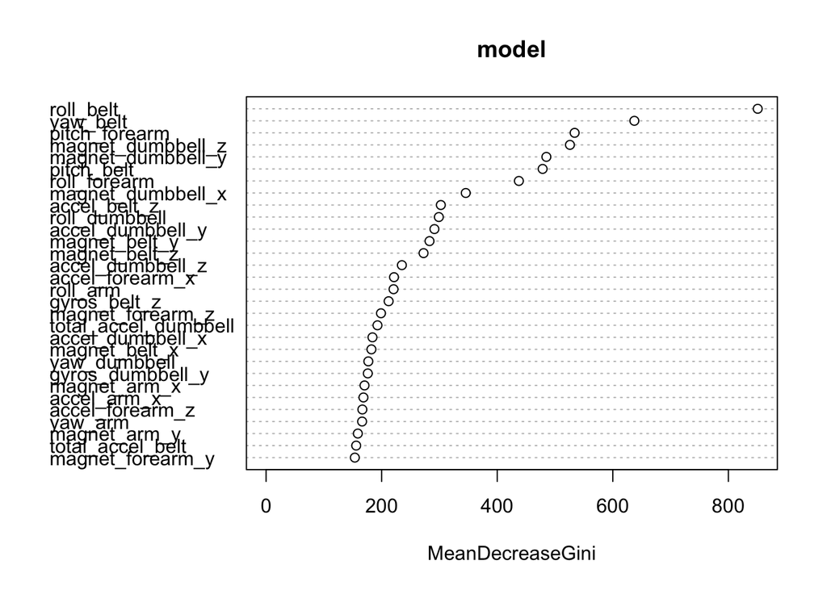

```r
varImpPlot(model,type=2)
```

## Validation

With the model created is time to validate it using the validation_dataset to predict the classe. Following the confussion matrix shows that the models works very good with the validation_dataset:

```r
predictions=predict(model,newdata=validate_dataset)
confusionMatrix(predictions,validate_dataset$classe)
```

```
## Confusion Matrix and Statistics
##
##           Reference
## Prediction    A    B    C    D    E
##          A 1672    8    0    0    0
##          B    1 1126    6    0    0
##          C    0    5 1018    8    1
##          D    0    0    2  956    3
##          E    1    0    0    0 1078
##
## Overall Statistics
##
##                Accuracy : 0.9941
##                  95% CI : (0.9917, 0.9959)
##     No Information Rate : 0.2845
##     P-Value [Acc > NIR] : < 2.2e-16
##
##                   Kappa : 0.9925
##  Mcnemar's Test P-Value : NA
##
## Statistics by Class:
##
##                      Class: A Class: B Class: C Class: D Class: E
## Sensitivity            0.9988   0.9886   0.9922   0.9917   0.9963
## Specificity            0.9981   0.9985   0.9971   0.9990   0.9998
## Pos Pred Value         0.9952   0.9938   0.9864   0.9948   0.9991
## Neg Pred Value         0.9995   0.9973   0.9984   0.9984   0.9992
## Prevalence             0.2845   0.1935   0.1743   0.1638   0.1839
## Detection Rate         0.2841   0.1913   0.1730   0.1624   0.1832
## Detection Prevalence   0.2855   0.1925   0.1754   0.1633   0.1833
## Balanced Accuracy      0.9985   0.9936   0.9947   0.9953   0.9980
```

## Predictions

With a validated model we only have to apply the model to the prediction dataset and classify the testing_complete_dataset

```r
predictions=predict(model,newdata=test_complete_dataset)
predictions
```

```
##  1  2  3  4  5  6  7  8  9 10 11 12 13 14 15 16 17 18 19 20
##  B  A  B  A  A  E  D  B  A  A  B  C  B  A  E  E  A  B  B  B
## Levels: A B C D E
```

## Conclusions

This project has shown the use of machine learning to automatically classify a dataset based on the data characteristics. Initially some cleaning task have been applied to the test dataset. Then from the training dataset a predictor Random Forest model has been created. According to this model the predictor has an error of 0.53%. After the model creation, this model has been applied to a testing dataset in order to predict the values.